# ML_model

Jake Dougherty

March 10, 2019

# Reading and splitting the data

- Removing non numberic columns for simplicity.
- Splitting the data in a train and test set.
- Since the given test set only contains 20 values and no responces, we have to split from the training set.

```r
data <- read.csv("pml-training.csv")

data <- data %>% dplyr::select(-cvtd_timestamp, -new_window)

testing_final <- read.csv("pml-testing.csv")


inTrain <- createDataPartition(data$classe, p = .7, list = F)

training <- data[inTrain,]
testing <- data[-inTrain,]
```

# Data Preprocessing

Many columns have mostly missing values. We want to measure which columns have many NAs, Some aren’t counted in NAs. The function below replaces the blanks with NAs

```r
#Replace blanks with NAs
training <- data.frame(sapply(training, function(f){is.na(f)<-which(f == "");f}) )

#Find the columns with high %ge of NAs
na_percents <- sapply(training, function(x) sum(is.na(x))/length(x) )

ind <- which(na_percents > 0)

only_nas <- training[,ind]
```

It turns out some columns are almost only NAs, while the others have no NAs. The problematic columns are removed.

```r
training_cleaned <- training[,-ind]

summary(training_cleaned)
```

```
##        X           user_name     raw_timestamp_part_1 raw_timestamp_part_2
##  Min.   :    1   Min.   :1.000   Min.   :1.322e+09    Min.   :   294
##  1st Qu.: 4887   1st Qu.:2.000   1st Qu.:1.323e+09    1st Qu.:252344
##  Median : 9825   Median :3.000   Median :1.323e+09    Median :500318
##  Mean   : 9808   Mean   :3.342   Mean   :1.323e+09    Mean   :500827
##  3rd Qu.:14698   3rd Qu.:5.000   3rd Qu.:1.323e+09    3rd Qu.:750623
##  Max.   :19622   Max.   :6.000   Max.   :1.323e+09    Max.   :998750
##    num_window      roll_belt        pitch_belt          yaw_belt
##  Min.   :  1.0   Min.   :-28.90   Min.   :-55.8000   Min.   :-180.00
##  1st Qu.:220.0   1st Qu.:  1.10   1st Qu.:  1.7900   1st Qu.: -88.30
##  Median :424.0   Median :114.00   Median :  5.3000   Median : -12.50
##  Mean   :429.4   Mean   : 64.65   Mean   :  0.2732   Mean   : -10.94
##  3rd Qu.:641.0   3rd Qu.:123.00   3rd Qu.: 14.9000   3rd Qu.:  13.60
##  Max.   :864.0   Max.   :162.00   Max.   : 60.3000   Max.   : 179.00
##  total_accel_belt  gyros_belt_x       gyros_belt_y       gyros_belt_z
##  Min.   : 0.00    Min.   :-1.04000   Min.   :-0.51000   Min.   :-1.350
##  1st Qu.: 3.00    1st Qu.:-0.03000   1st Qu.: 0.00000   1st Qu.:-0.200
##  Median :17.00    Median : 0.03000   Median : 0.02000   Median :-0.100
##  Mean   :11.34    Mean   :-0.00614   Mean   : 0.03951   Mean   :-0.131
##  3rd Qu.:18.00    3rd Qu.: 0.11000   3rd Qu.: 0.11000   3rd Qu.:-0.020
##  Max.   :29.00    Max.   : 2.02000   Max.   : 0.64000   Max.   : 1.610
##   accel_belt_x      accel_belt_y     accel_belt_z     magnet_belt_x
##  Min.   :-82.000   Min.   :-69.00   Min.   :-275.00   Min.   :-52.00
##  1st Qu.:-21.000   1st Qu.:  3.00   1st Qu.:-162.00   1st Qu.:  9.00
##  Median :-15.000   Median : 35.00   Median :-153.00   Median : 35.00
##  Mean   : -5.577   Mean   : 30.19   Mean   : -72.97   Mean   : 55.76
##  3rd Qu.: -5.000   3rd Qu.: 61.00   3rd Qu.:  27.00   3rd Qu.: 59.00
##  Max.   : 79.000   Max.   :149.00   Max.   : 105.00   Max.   :485.00
##  magnet_belt_y   magnet_belt_z     roll_arm         pitch_arm
##  Min.   :354.0   Min.   :-623   Min.   :-180.00   Min.   :-88.800
##  1st Qu.:582.0   1st Qu.:-374   1st Qu.: -31.80   1st Qu.:-25.900
##  Median :601.0   Median :-319   Median :   0.00   Median :  0.000
##  Mean   :593.8   Mean   :-345   Mean   :  17.77   Mean   : -4.705
##  3rd Qu.:610.0   3rd Qu.:-306   3rd Qu.:  77.30   3rd Qu.: 11.000
##  Max.   :673.0   Max.   : 293   Max.   : 180.00   Max.   : 86.800
##     yaw_arm          total_accel_arm  gyros_arm_x        gyros_arm_y
##  Min.   :-180.0000   Min.   : 1.00   Min.   :-6.37000   Min.   :-3.4400
##  1st Qu.: -42.6000   1st Qu.:17.00   1st Qu.:-1.32000   1st Qu.:-0.8000
##  Median :   0.0000   Median :27.00   Median : 0.08000   Median :-0.2600
##  Mean   :  -0.3667   Mean   :25.47   Mean   : 0.04952   Mean   :-0.2597
```

[output cut: 50 more lines]

```
##  Max.   :79.00       Max.   : 3.9700   Max.   : 6.13000
##  gyros_forearm_z   accel_forearm_x  accel_forearm_y  accel_forearm_z
##  Min.   :-8.0900   Min.   :-498.0   Min.   :-595.0   Min.   :-446.00
##  1st Qu.:-0.1800   1st Qu.:-178.0   1st Qu.:  57.0   1st Qu.:-182.00
##  Median : 0.0800   Median : -57.0   Median : 201.0   Median : -41.00
##  Mean   : 0.1417   Mean   : -61.9   Mean   : 164.8   Mean   : -56.46
##  3rd Qu.: 0.4900   3rd Qu.:  75.0   3rd Qu.: 313.0   3rd Qu.:  25.00
##  Max.   : 4.3100   Max.   : 477.0   Max.   : 591.0   Max.   : 291.00
##  magnet_forearm_x magnet_forearm_y magnet_forearm_z     classe
##  Min.   :-1280    Min.   :-896.0   Min.   :-973.0   Min.   :1.000
##  1st Qu.: -615    1st Qu.:  10.0   1st Qu.: 205.0   1st Qu.:1.000
##  Median : -383    Median : 594.0   Median : 514.0   Median :3.000
##  Mean   : -314    Mean   : 381.8   Mean   : 398.6   Mean   :2.769
##  3rd Qu.:  -78    3rd Qu.: 737.0   3rd Qu.: 653.0   3rd Qu.:4.000
##  Max.   :  672    Max.   :1480.0   Max.   :1090.0   Max.   :5.000
```

```r
sum(is.na(training_cleaned))
```

```
## [1] 0
```

# Examining correlated predictors.

Removing unessisary columns, we use a correlation matrix and plot it using the corrplot function from the corrplot package. The function top_cor is user defined and can be found in the corrFuns.R file, it uses a rule of thumb for removing corrilated predictors given in the textbook Applied Predictive modeling. The first correlation matrix shows lots of heavy shaded areas, where the second one with the removed columns are a lot less correlated.

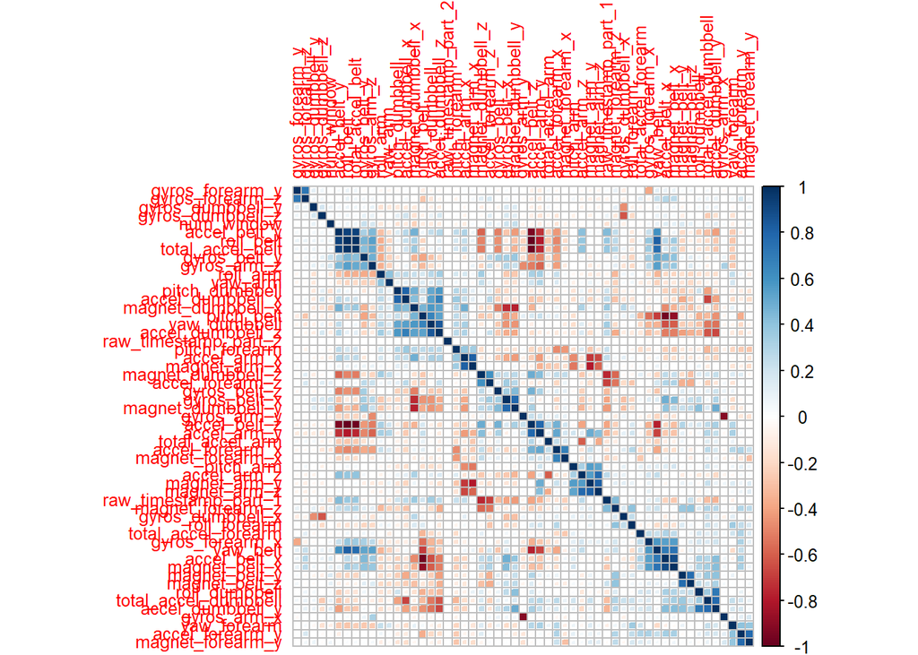

```r
cor_mat <- cor(dplyr::select(training_cleaned,c(-1, -2,-classe)))

corrplot::corrplot(cor_mat, method = "square", type = "full", tl.cex = .8, order = "hclust")
```

```r
colnms <- top_cor(cor.mat = cor_mat, drop = T, thresh = .85)
```

```
## [1] -0.9919595
## [1] -0.9757082
## [1] -0.9666194
## [1] -0.9348023
## [1] -0.9189099
## [1] -0.8843979
```

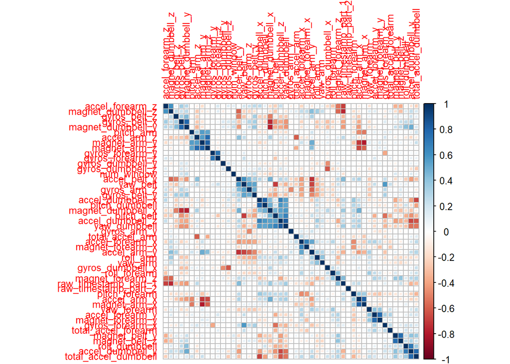

```r
training_cleaned <- training_cleaned[,c("X", "user_name", colnms, "classe")]

cor_mat <- cor(training_cleaned[,c(-1, -2,-ncol(training_cleaned))])

corrplot::corrplot(cor_mat, method = "square", type = "full", tl.cex = .8, order = "hclust")
```

# Training and tuning

Unessisary columns are removed. A trainControl object is created specifying to use 10 fold cross validation. This breaks the data up into 10 smaller dataset using the training data with resampling. This ensures that the model is tested on additional test sets

```r
colnms2 <- paste(colnms, collapse = "+")

training_cleaned$classe <- factor(training_cleaned$classe)

training_final <- training_cleaned[,c(-1,-2)]

str(training_final)
```

```
## 'data.frame':    13737 obs. of  50 variables:
##  $ accel_arm_x         : num  -288 -290 -289 -289 -289 -288 -288 -290 -287 -289 ...
##  $ accel_arm_y         : num  109 110 111 111 111 109 110 110 111 111 ...
##  $ accel_arm_z         : num  -123 -125 -122 -125 -124 -122 -124 -123 -124 -124 ...
##  $ accel_belt_y        : num  4 4 4 3 4 2 4 2 4 2 ...
##  $ accel_dumbbell_x    : num  -234 -233 -234 -232 -234 -232 -235 -233 -234 -234 ...
##  $ accel_dumbbell_y    : num  47 47 48 47 46 47 48 47 48 47 ...
##  $ accel_dumbbell_z    : num  -271 -269 -269 -270 -272 -269 -270 -269 -269 -270 ...
##  $ accel_forearm_x     : num  192 192 193 195 193 193 190 193 193 192 ...
##  $ accel_forearm_y     : num  203 203 203 205 205 204 205 205 205 201 ...
##  $ accel_forearm_z     : num  -215 -216 -215 -215 -213 -214 -215 -214 -215 -214 ...
##  $ gyros_arm_y         : num  0 -0.02 -0.03 -0.03 -0.02 -0.03 -0.03 -0.03 -0.02 0 ...
##  $ gyros_arm_z         : num  -0.02 -0.02 0 0 0 -0.02 -0.02 0 -0.02 -0.03 ...
##  $ gyros_belt_x        : num  0 0.02 0.02 0.02 0.02 0.02 0.03 0.03 0.02 0 ...
##  $ gyros_belt_y        : num  0 0 0 0 0 0 0 0 0 0 ...
```

[output cut: 36 more lines]

```r
train_control <- trainControl(method="cv", number=10, savePredictions = TRUE)
```

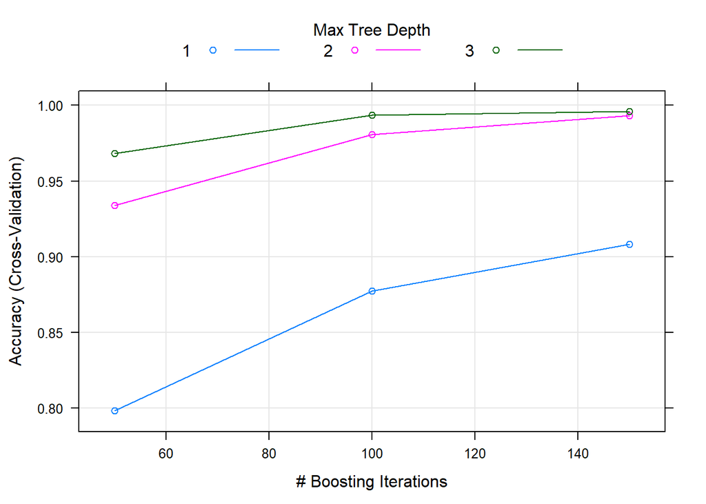

```r
gbm <- train(classe ~. , data = training_final,
             method = "gbm", verbose = F,
              preProcess = c("scale", "center"), trControl = train_control)

rf <- train(classe ~. , data = training_final,
             method = "gbm", verbose = F,
             preProcess = c("scale", "center"), trControl = train_control)

testing$gbm_pred <- predict(gbm,testing)
testing$rf_pred <- predict(rf,testing)

caret::plot.train(gbm)
```

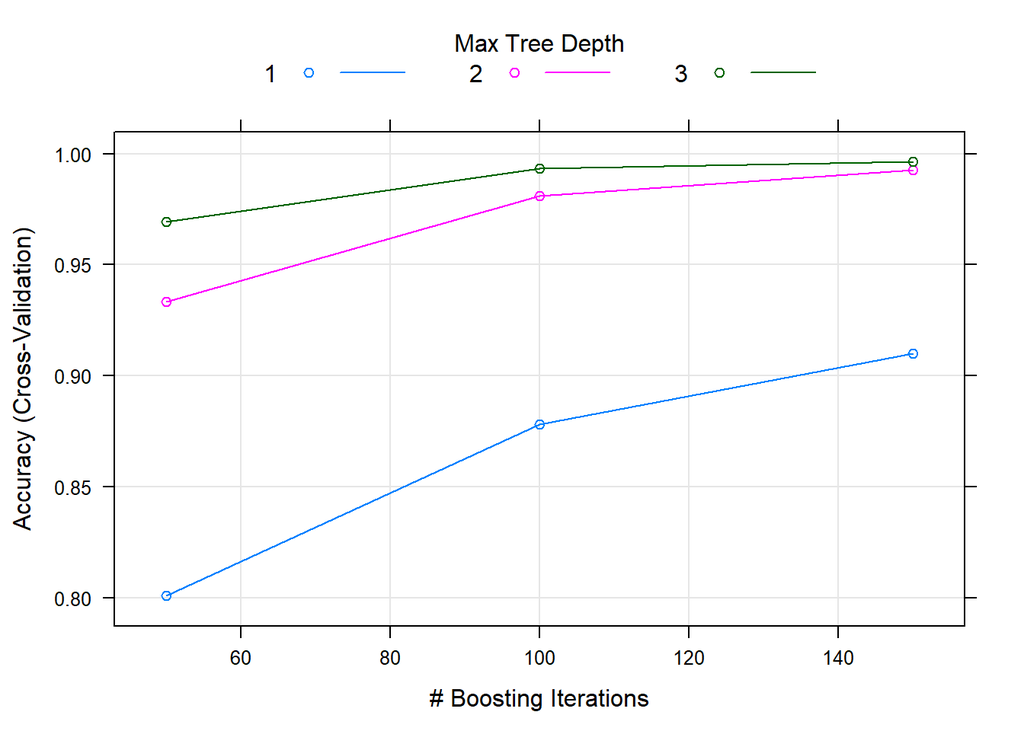

```r
caret::plot.train(rf)
```

# Model evaluation and selection

```r
levels(testing$gbm_pred) <- c("A", "B", "C", "D", "E")
levels(testing$rf_pred) <- c("A", "B", "C", "D", "E")

confusionMatrix(testing$gbm_pred, testing$classe)
```

```
## Confusion Matrix and Statistics
##
##           Reference
## Prediction    A    B    C    D    E
##          A 1674    1    0    0    0
##          B    0 1134    2    0    0
##          C    0    4 1021    7    0
##          D    0    0    3  954    4
##          E    0    0    0    3 1078
##
## Overall Statistics
##
##                Accuracy : 0.9959
##                  95% CI : (0.9939, 0.9974)
##     No Information Rate : 0.2845
##     P-Value [Acc > NIR] : < 2.2e-16
##
##                   Kappa : 0.9948
##  Mcnemar's Test P-Value : NA
##
## Statistics by Class:
##
##                      Class: A Class: B Class: C Class: D Class: E
## Sensitivity            1.0000   0.9956   0.9951   0.9896   0.9963
## Specificity            0.9998   0.9996   0.9977   0.9986   0.9994
## Pos Pred Value         0.9994   0.9982   0.9893   0.9927   0.9972
## Neg Pred Value         1.0000   0.9989   0.9990   0.9980   0.9992
## Prevalence             0.2845   0.1935   0.1743   0.1638   0.1839
## Detection Rate         0.2845   0.1927   0.1735   0.1621   0.1832
## Detection Prevalence   0.2846   0.1930   0.1754   0.1633   0.1837
## Balanced Accuracy      0.9999   0.9976   0.9964   0.9941   0.9978
```

```r
confusionMatrix(testing$rf_pred, testing$classe)
```

```
## Confusion Matrix and Statistics
##
##           Reference
## Prediction    A    B    C    D    E
##          A 1674    1    0    0    0
##          B    0 1134    0    0    0
##          C    0    4 1023    6    0
##          D    0    0    3  955    4
##          E    0    0    0    3 1078
##
## Overall Statistics
##
##                Accuracy : 0.9964
##                  95% CI : (0.9946, 0.9978)
##     No Information Rate : 0.2845
##     P-Value [Acc > NIR] : < 2.2e-16
##
##                   Kappa : 0.9955
##  Mcnemar's Test P-Value : NA
##
## Statistics by Class:
##
##                      Class: A Class: B Class: C Class: D Class: E
## Sensitivity            1.0000   0.9956   0.9971   0.9907   0.9963
## Specificity            0.9998   1.0000   0.9979   0.9986   0.9994
## Pos Pred Value         0.9994   1.0000   0.9903   0.9927   0.9972
## Neg Pred Value         1.0000   0.9989   0.9994   0.9982   0.9992
## Prevalence             0.2845   0.1935   0.1743   0.1638   0.1839
## Detection Rate         0.2845   0.1927   0.1738   0.1623   0.1832
## Detection Prevalence   0.2846   0.1927   0.1755   0.1635   0.1837
## Balanced Accuracy      0.9999   0.9978   0.9975   0.9946   0.9978
```

```r
predict(rf, testing_final)
```

```
##  [1] 2 1 2 1 1 5 4 2 1 1 2 3 2 1 5 5 1 2 2 2
## Levels: 1 2 3 4 5
```